# Data Integration

## PCA

```python
# ---
# PCA
# ---

pca = PCA(n_components=2)
pca.fit(dr_matrix)

Y_pca = pca.transform(dr_matrix)
pc1 = round(pca.explained_variance_ratio_[0] * 100, 2)  # %variance explained
pc2 = round(pca.explained_variance_ratio_[1] * 100, 2)

# Join PCA coordinates with EMD dataframe
Y_pca_df = pd.DataFrame(Y_pca).reset_index()
emd_df_master_wide = emd_df_master_wide.reset_index(drop=True).reset_index()
Y_pca_df = pd.merge(emd_df_master_wide, Y_pca_df, on="index")
Y_pca_df.drop(columns=["index"], inplace=True)
emd_df_master_wide.drop(columns="index", inplace=True)
Y_pca_df.head()
```

|  | 106Cd_RFP | 110Cd_mCherry | 111Cd_CD44 | 113In_CEACAM1_CD66a | 115In_Pan-CK | 116Cd_GFP | 127I_IdU | 140Ce_EQ_Beads | 141Pr_pPDPK1_S241 | 142Nd_cCaspase_3_D175 | ... | W | E | N | R | genotype | A | K | P | 0 | 1 |
| --- | --- | --- | --- | --- | --- | --- | --- | --- | --- | --- | --- | --- | --- | --- | --- | --- | --- | --- | --- | --- | --- |
| 0 | -0.986058 | -0.628535 | -0.433836 | -0.504271 | -1.790652 | 0.994797 | 1.807202 | -0.373039 | -0.310499 | -0.547218 | ... | 0 | 0 | 0 | 0 | AKP | 1 | 1 | 1 | -3.179944 | 0.088687 |
| 1 | -1.092866 | -0.740317 | 0.337521 | -0.218562 | -1.868445 | 0.930249 | 1.453221 | 0.008196 | -0.694960 | -0.122425 | ... | 0 | 1 | 1 | 1 | AKP | 1 | 1 | 1 | -3.880972 | 1.077581 |
| 2 | -1.110171 | -0.802604 | 0.144034 | -0.056205 | -1.395733 | 0.882821 | 1.330699 | -0.612791 | -0.714967 | -0.984950 | ... | 0 | 1 | 0 | 0 | AKP | 1 | 1 | 1 | -2.875727 | -0.115432 |
| 3 | -1.038874 | -0.657636 | -0.665771 | -0.546193 | -1.551713 | 0.971222 | 1.682297 | -0.844182 | -0.509220 | -1.130203 | ... | 0 | 0 | 1 | 0 | AKP | 1 | 1 | 1 | -2.746916 | -0.436764 |
| 4 | -1.128610 | -0.735553 | -0.551828 | -0.546722 | -1.539257 | 0.929135 | 1.699928 | -0.817110 | -0.764586 | -0.912786 | ... | 0 | 0 | 0 | 1 | AKP | 1 | 1 | 1 | -3.047900 | -0.219352 |

5 rows × 66 columns

### Signalling (Grouped)

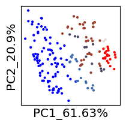

```python
# PHATE preview
fig = scprep.plot.scatter2d(
    Y_pca_df.iloc[:, -2:],
    c=Y_pca_df.loc[:, "culture"],
    cmap=colours,
    ticks=False,
    xlabel=f"PC1_{pc1}%",
    ylabel=f"PC2_{pc2}%",
    s=4,
    legend=False,
    figsize=(2.2, 2.2),
)
```

### Genotype

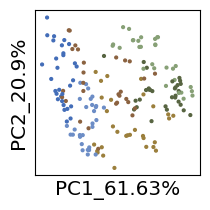

```python
fig = scprep.plot.scatter2d(
    Y_pca_df.iloc[:, -2:],
    c=Y_pca_df.loc[:, "genotype"],
    cmap=colours,
    ticks=False,
    xlabel=f"PC1_{pc1}%",
    ylabel=f"PC2_{pc2}%",
    s=4,
    legend=False,
    figsize=(2.2, 2.2),
)
```

### Ligand

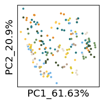

```python
fig = scprep.plot.scatter2d(
    Y_pca_df.iloc[:, -2:],
    c=Y_pca_df.loc[:, "media"],
    cmap=colours,
    ticks=False,
    xlabel=f"PC1_{pc1}%",
    ylabel=f"PC2_{pc2}%",
    s=4,
    legend=False,
    figsize=(2.2, 2.2),
)
```

### Selected Markers

- revCSC: CLU, pGSK-3β [S9]
- Equilibrium: Pan-CK, FABP2, pNDRG1 [T346], pMKK3/6 [S189/207]
- proCSC: LRIG1, SURVIVIN, EPHB2, IdU, pMK2 [T334], pAKT [T308]

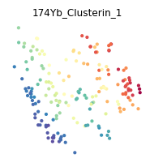

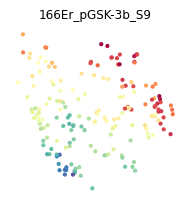

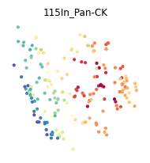

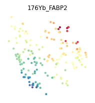

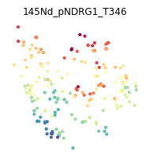

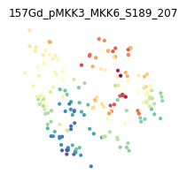

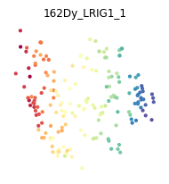

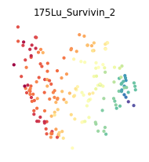

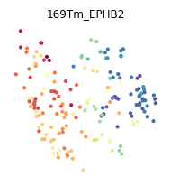

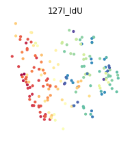

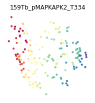

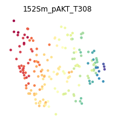

```python
marker_list = [
    "174Yb_Clusterin_1",
    "166Er_pGSK-3b_S9",
    "115In_Pan-CK",
    "176Yb_FABP2",
    "145Nd_pNDRG1_T346",
    "157Gd_pMKK3_MKK6_S189_207",
    "162Dy_LRIG1_1",
    "175Lu_Survivin_2",
    "169Tm_EPHB2",
    "127I_IdU",
    "159Tb_pMAPKAPK2_T334",
    "152Sm_pAKT_T308"
    ]

for marker in marker_list:
    fig, ax = plt.subplots(1, 1, figsize=(2.2, 2.2))
    fig = scprep.plot.scatter2d(
        Y_pca_df.iloc[:, -2:],
        c=Y_pca_df.loc[:, marker],
        cmap=sns.color_palette("Spectral_r", as_cmap=True),
        ticks=False,
        s=4,
        xlabel="",
        ylabel="",
        legend=False,
        title=marker,
        fontsize=5,
        # legend_ncol=2,
        ax=ax,
    )
    fig.axis("off")
```

## Figure S3 - WT Monoculture vs Co-culture

```python
# Import data
base_dir = "/Users/xiaoqin/Dropbox/TAPE LAB/Manuscripts/Qin & Cardoso Rodriguez et al/SupplementaryMaterials/Qin-CardosoRodriguez-et-al_analysis/Figure3-4_S3-S4/WENR Permutation"
input_dir = f"{base_dir}/output/emd"
output_dir = f"{base_dir}/output/"

# Set experimental metadata
norm = "z-score"

emd_df_master_wide = pd.read_csv(f"{input_dir}/emd_df_master_all-cells_{norm}.csv")

# Subset on WT
emd_df_wt = emd_df_master_wide[emd_df_master_wide["genotype"]=="WT"]
emd_df_master_wide=emd_df_wt.copy()
```

```python
# Define markers used for PHATE
dr_panel = [
    # cell-state
    '89Y_pHH3_S28',
    '127I_IdU',
    '142Nd_cCaspase_3_D175',
    '150Nd_pRB_S807_S811',
    '172Yb_cCaspase_8_D387',
    '173Yb_Cyclin_B1_2',
    # cell-type
    '143Nd_C-MYC_1',
    '111Cd_CD44',
    '162Dy_LRIG1_1',
    '169Tm_EPHB2',
    '171Yb_SOX9_5',
    '174Yb_Clusterin_1',
    '175Lu_Survivin_2',
    '176Yb_FABP2',
    '113In_CEACAM1_CD66a',
    '115In_Pan-CK',
    # '116Cd_GFP', # GFP excluded
    # PTMs
    '141Pr_pPDPK1_S241',
    '145Nd_pNDRG1_T346',
    '146Nd_pMKK4_SEK1_S257',
    '147Sm_pBTK_Y511_1',
    '148Nd_pSRC_Y418',
    '149Sm_p4EBP1_T37_T46',
    '151Eu_pPKCa_T497',
    '152Sm_pAKT_T308',
    '153Eu_pCREB_S133',
    '154Sm_pSMAD1_5_9',
    '155Gd_pAKT_S473_3',
    '156Gd_pNF-kB_p65_S529',
    '157Gd_pMKK3_MKK6_S189_207',
    '158Gd_pP38_MAPK_T180_Y182',
    '159Tb_pMAPKAPK2_T334',
    '160Gd_pAMPKa_T172',
    '161Dy_pBAD_S112',
    '163Dy_pP90RSK_T359_Hu',
    '164Dy_pP120-Catenin_T310',
    '165Ho_Beta-catenin_Active_1',
    '166Er_pGSK-3b_S9',
    '167Er_pERK_1_2_T202_Y204',
    '168Er_pSMAD2_3',
    '170Er_pMEK1_2_S221',
    '209Bi_DiMeHH3_K4'
]

dr_matrix = master_df_subset(emd_df_master_wide, dr_panel)
```

## PHATE

```python
phate_operator = phate.PHATE(
    knn=5, t=10, random_state=42, mds_solver="smacof", verbose=False
)
Y_phate = phate_operator.fit_transform(dr_matrix)

# Join PHATE coordinates with EMD dataframe
Y_phate_df = pd.DataFrame(Y_phate).reset_index()
emd_df_master_wide = emd_df_master_wide.reset_index(drop=True).reset_index()
Y_phate_df = pd.merge(emd_df_master_wide, Y_phate_df, on="index")
Y_phate_df.drop(columns=["index"], inplace=True)
emd_df_master_wide.drop(columns="index", inplace=True)
Y_phate_df.head()
```

|  | 106Cd_RFP | 110Cd_mCherry | 111Cd_CD44 | 113In_CEACAM1_CD66a | 115In_Pan-CK | 116Cd_GFP | 127I_IdU | 140Ce_EQ_Beads | 141Pr_pPDPK1_S241 | 142Nd_cCaspase_3_D175 | ... | W | E | N | R | genotype | A | K | P | 0 | 1 |
| --- | --- | --- | --- | --- | --- | --- | --- | --- | --- | --- | --- | --- | --- | --- | --- | --- | --- | --- | --- | --- | --- |
| 0 | -0.150404 | -0.289963 | 0.446275 | -0.066805 | 0.572189 | -1.116779 | -1.267079 | 1.264548 | 0.551637 | 0.915658 | ... | 0 | 0 | 0 | 0 | WT | 0 | 0 | 0 | 0.049580 | -0.056588 |
| 1 | 0.002220 | -0.080041 | 1.386434 | -0.267351 | 0.644216 | -1.119105 | -1.277352 | 0.952712 | 0.535808 | 1.575212 | ... | 0 | 1 | 1 | 1 | WT | 0 | 0 | 0 | 0.142842 | 0.023638 |
| 2 | 0.209145 | 0.142751 | 1.767582 | 0.063891 | 0.771758 | -1.080494 | -1.186954 | 0.509612 | 1.387442 | 1.722054 | ... | 0 | 1 | 0 | 0 | WT | 0 | 0 | 0 | 0.167792 | 0.059195 |
| 3 | -0.086943 | -0.219809 | 0.464098 | -0.180954 | 0.729358 | -1.081009 | -0.933995 | 1.288391 | 0.743318 | 1.248293 | ... | 0 | 0 | 1 | 0 | WT | 0 | 0 | 0 | 0.057698 | -0.052332 |
| 4 | -0.103764 | -0.223331 | 0.637752 | -0.213370 | 0.532355 | -1.112544 | -0.933600 | 0.960081 | 0.485205 | 0.875344 | ... | 0 | 0 | 0 | 1 | WT | 0 | 0 | 0 | 0.047688 | -0.057185 |

5 rows × 66 columns

### Figure S3D - Ligand vs Microenvironment (Grouped)

```
(-0.16182336463419264,
 0.18888617414025022,
 -0.07912898265728198,
 0.11527948718967063)
```

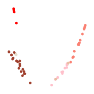

```python
fig = scprep.plot.scatter2d(
    Y_phate_df.iloc[:, -2:],
    c=emd_df_master_wide.loc[:, "culture"],
    cmap=colours,
    ticks=False,
    s=7,
    label=None,
    legend=False,
    figsize=(2.2, 2.2),
)
fig.axis('off')
```

### Figure S3E - Ligand

```
(-0.16182336463419264,
 0.18888617414025022,
 -0.07912898265728198,
 0.11527948718967063)
```

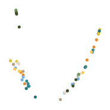

```python
fig = scprep.plot.scatter2d(
    Y_phate_df.iloc[:, -2:],
    c=emd_df_master_wide.loc[:, "media"],
    cmap=colours,
    ticks=False,
    s=7,
    label=None,
    legend=False,
    figsize=(2.2, 2.2),
)
fig.axis('off')
```

### Figure S3F - Selected Markers

- revCSC: CLU, SOX9
- PTMs: pRB [S807/S811], pNDRG1 [T346], pMKK3/6 [S189/207], pP90RSK [T359], pGSK-3β [S9], pERK1/2 [T202/Y204], pMK2 [T334], pSMAD2/3 [S465/S467]

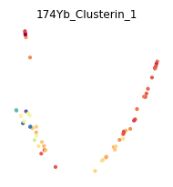

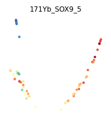

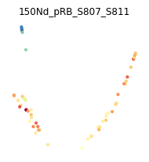

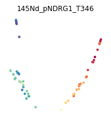

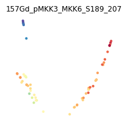

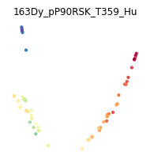

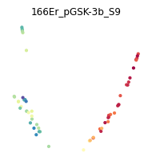

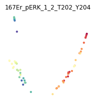

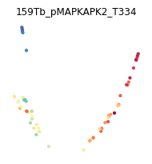

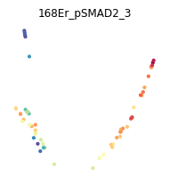

```python
marker_list = [
    "174Yb_Clusterin_1",
    "171Yb_SOX9_5",
    "150Nd_pRB_S807_S811",
    "145Nd_pNDRG1_T346",
    "157Gd_pMKK3_MKK6_S189_207",
    "163Dy_pP90RSK_T359_Hu",
    "166Er_pGSK-3b_S9",
    "167Er_pERK_1_2_T202_Y204",
    "159Tb_pMAPKAPK2_T334",
    "168Er_pSMAD2_3",
    ]

for marker in marker_list:
    fig, ax = plt.subplots(1, 1, figsize=(2.2, 2.2))
    fig = scprep.plot.scatter2d(
        Y_phate_df.iloc[:, -2:],
        c=Y_phate_df.loc[:, marker],
        cmap=sns.color_palette("Spectral_r", as_cmap=True),
        ticks=False,
        s=4,
        xlabel="",
        ylabel="",
        legend=False,
        title=marker,
        fontsize=5,
        # legend_ncol=2,
        ax=ax,
    )
    fig.axis("off")
```